# Green split into two donor-disjoint halves, twice: `raw` on an unfloored library and pseudobulk DESeq2 replicate best, `donor_wls` trails because of donors that are outliers on the log scale, and `state_adjusted` again has no signal that replicates

Kevin Z. Lin (drafted by Claude)

2026-11-16

# 1 Overview

This document is built from Kevin’s note of 2026-11-16 (`2026-11-16_autoresearch-green-replicate.txt`), from the Gabitto split-half study that it repeats (`../2026-11-15_gabitto/2026-11-15_gabitto-split-half_claude.Rmd`), from the two autoresearch loops on the reported log fold change and its standard error and the study that followed them (`2026-11-12_autoresearch_beyond-score_claude.Rmd`), and from Tati’s Writeup47 fit of the Green cohort (the design). The Green microglia are split into two halves that share no donor, each half is fitted by eSVD-DE on its own, and every rule is asked how well its logFC and SE from one half agree with those from the other. The split is done twice. The scripts, the statistics and the figures are those of the Gabitto study, so that the two cohorts can be read side by side.

**The question.** On a second real cohort, with five times as many donors as Gabitto and a third as many nuclei per donor, which rule’s log2 fold change and SE replicate best between two independent halves, and does the recommendation from Gabitto hold?

What the document argues:

1. **The cohort has a different shape from Gabitto.** Each half has 214 donors (75 to 77 controls) and about 41,000 nuclei, a median of 178 per donor. The nuisance rate is at the cap for 42% to 44% of the genes (17% in the Gabitto halves), the package’s test calls 94 to 182 genes per half at 5% FDR, and pseudobulk DESeq2 calls 63 to 84 (section 2.1).
2. **`state_adjusted` has the lowest replicate score again and almost no signal that replicates**, with 214 donors per half at rank 30: its halves correlate at 0.13 and 0.11 and a gene nominated by eSVD-DE’s test keeps its sign in the other half 52% and 59% of the time. A rank close to the number of donors is therefore not what removes the signal (section 4.1).
3. **Among the rules that keep a signal, `raw` on an unfloored library and pseudobulk DESeq2 score best, and `donor_wls@esvd_nofloor` is 0.05 nats behind `raw@esvd_nofloor`** (`raw@esvd_nofloor` -0.64 and -0.65, `deseq2` -0.65 and -0.67, `donor_wls@esvd_nofloor` -0.61 and -0.58, `stored` -0.26 and -0.26). On Gabitto `donor_wls@esvd_nofloor` was first (section 4.2).
4. **The posterior’s floor on the fitted library costs far more here than on Gabitto**: 0.25 and 0.40 nats for `donor_wls` and 0.13 and 0.21 for `raw` (section 4.2).
5. **`donor_wls` trails because a few donors lie far from the others on the log scale.** For the genes with under 80% zeros its halves correlate at 0.16 and -0.21 with the summed-count library, against 0.45 and 0.39 for `raw` with the same library. Winsorizing each gene’s log donor means brings `donor_wls` to 0.32 and 0.34, and without the donor-level covariates to 0.50 and 0.48. The same change does nothing on Gabitto (section 4.6).
6. **The SEs of `raw@esvd_nofloor`, `donor_wls@esvd_nofloor` and DESeq2 are within 8% of the disagreement between the halves**, and the `stored` SE is twice too large (`z_rms` 0.50 and 0.52; section 4.4).
7. **A gene that eSVD-DE’s test calls in one half keeps its sign in the other half 79% and 88% of the time.** The two flags that separated the calls on Gabitto (a nuisance rate at the cap, no support from `donor_wls`) do not separate them here (section 4.5).
8. **The recommendation**: on this cohort the pair to report is `raw@esvd_nofloor`; `donor_wls@esvd_nofloor` is close and needs a guard against outlying donors before it is used on a cohort of this shape. The simulated bank needs donors that are outliers on the log scale, many donors of few cells, and a capped share near 40% (section 5).

*How to read.* The blue box says how the cohort was split; green boxes close each results subsection with what it changes; the orange box in section 5 is the procedure. A reader of the boxes alone has the argument.

| Stage | What it does | Section |
| --- | --- | --- |
| Definitions | the cohort, the two splits, the four fits, the rules, the statistics | 2 |
| Each rule | the two halves against each other, one subsection per rule | 3 |
| Side by side | the score, the correlation, the SE, the sign of the nominated genes, the diagnosis of `donor_wls`, Green beside Gabitto | 4 |
| Recommendation | the rule to report from and what the bank should add | 5 |

# 2 Definitions

## 2.1 The cohort and the two splits

The data are the microglia of the ROSMAP cohort of Green et al. (2024) as cleaned for the Was2CoDE analysis (`Writeup43_green_cleaned_only-counts.RData`): 81,625 nuclei of 428 donors and 5,256 genes, the same genes as the Gabitto study. A donor is a case when `AD_path_cerad` is `TRUE` (276 donors) and a control otherwise (152 donors), the definition of Tati’s Writeup47 fit of the whole cohort. A donor has a median of 178 nuclei, against about 500 in Gabitto.

The 428 donors fall into eight strata of CERAD arm, sex and APOE4 status, as in the Gabitto study. Within each stratum the donors are permuted and dealt alternately to two halves, and the half that receives the first donor alternates over the strata with an odd count so that the leftover donors do not all land in one half. A donor is therefore in exactly one half of a split. The procedure is run twice with different seeds (`split1`, seed 10; `split2`, seed 20), and 196 of the 428 donors keep their half label between the two splits. Each of the four halves is then fitted on its own with `eSVD2::eSVD_helper()` of version 1.2.0 at the settings of Writeup47: `k = 30`, covariates `msex`, `APOEe4_status`, `pmi` and `age_death`, every other argument at its default.

Table 1. The donors of each half, by arm. PMI and age at death were not stratified on.

| split | half | arm | num_donors | num_cells | num_female | num_apoe4 | mean_pmi | mean_age |
| --- | --- | --- | --- | --- | --- | --- | --- | --- |
| split1 | 1 | FALSE | 75 | 14008 | 46 | 9 | 6.95 | 86.03 |
| split1 | 1 | TRUE | 139 | 27563 | 99 | 47 | 7.66 | 87.51 |
| split1 | 2 | FALSE | 77 | 13683 | 47 | 9 | 7.83 | 85.29 |
| split1 | 2 | TRUE | 137 | 26371 | 97 | 46 | 7.75 | 87.73 |
| split2 | 1 | FALSE | 76 | 13864 | 47 | 9 | 7.76 | 86.11 |
| split2 | 1 | TRUE | 138 | 26924 | 98 | 46 | 7.79 | 88.19 |
| split2 | 2 | FALSE | 76 | 13827 | 46 | 9 | 7.03 | 85.20 |
| split2 | 2 | TRUE | 138 | 27010 | 98 | 47 | 7.62 | 87.04 |

Table 2. The four fits. `null_mean` and `null_sd` are the empirical null of the package’s test; `share_capped` is the share of genes whose nuisance rate sits at the cap; the last two columns count the genes called at 5% FDR by the package’s test and by pseudobulk DESeq2.

| fit | num_case | num_control | num_cells | num_genes | fit_minutes | null_mean | null_sd | share_capped | num_esvd_deg | num_deseq2_deg |
| --- | --- | --- | --- | --- | --- | --- | --- | --- | --- | --- |
| split1_half1 | 139 | 75 | 41571 | 5256 | 83 | -0.11 | 0.52 | 0.42 | 95 | 82 |
| split1_half2 | 137 | 77 | 40054 | 5256 | 66 | -0.06 | 0.46 | 0.44 | 182 | 70 |
| split2_half1 | 138 | 76 | 40788 | 5256 | 82 | -0.10 | 0.59 | 0.43 | 95 | 84 |
| split2_half2 | 138 | 76 | 40837 | 5256 | 67 | -0.04 | 0.44 | 0.43 | 94 | 63 |

## 2.2 The rules

Every rule is the file the loops left, unedited, applied as in the beyond-score study (`2026-11-12_autoresearch_beyond-score_claude.Rmd`, section 2.2) and in the Gabitto study.

| Name in the tables | Rule | Reads of the fit |
| --- | --- | --- |
| `stored` | what 1.2.0 reports: log ratio of the arms’ mean posterior, SE from the posterior’s mixture variances | posterior |
| `null_rescaled` | `stored`, the logFC shifted by the empirical null’s mean and the SE multiplied by its SD | posterior, empirical null |
| `deshrunk` | `stored`’s logFC; between-donor SE of the posterior donor means divided by the shrinkage weight | posterior, library, nuisance rate |
| `raw` | ratio of the arms’ means of donor means of $A/\ell$, delta-method SE between donors | library |
| `raw_null` | `raw` with the empirical null’s shift and rescaling | library |
| `donor_wls` | weighted regression of $\log\{(y_{dg} + 1/2)/L_{dg}\}$ on the arm and the donor-level covariates, residual variance moderated across genes, logFC shifted by the null’s mean | library |
| `gap_trend` | as `donor_wls` with voom-style weights and a variance trend in a covariate that contains the between-arm gap | library |
| `embed_prior` | `donor_wls` with the embedding’s predicted donor variance in the moderation prior | library, embedding |
| `state_adjusted` | `donor_wls` on summaries with the embedding’s donor offset removed; the arm coefficients’ component along the loadings subtracted | library, embedding |
| `deseq2` | DESeq2 on donor pseudobulk; design: sex, APOE4 status, PMI, age at death and the arm | nothing |

Here $y_{dg}$ is the donor’s summed count and $L_{dg}$ its summed library. A suffix names the library a library-reading rule was handed in place of the fitted one: `@esvd_nofloor` (the fitted library before the posterior’s floor at 0.1), `@esvd_depth` (the fitted intercept and depth alone), `@total` (the cell’s summed counts), `@sf` and `@tmm` (summed counts rescaled to DESeq2’s size factors or edgeR’s TMM factors of the donor pseudobulk). `raw` is also run with `@esvd_nofloor` and `@total`, so that it and `donor_wls` can be compared on one library; the Gabitto study was rerun with the same two variants. Every covariate of this design is constant within a donor, so the `_cov` variants of the beyond-score study coincide with the plain ones.

## 2.3 What is compared between the two halves

For one rule and one split, gene $g$ has the pair $(\widehat{\beta}_{g1}, s_{g1})$ from half 1 and $(\widehat{\beta}_{g2}, s_{g2})$ from half 2, on the $\log_2$ scale. The two halves share no donor, so the two estimates are independent given the population’s effect.

**The replicate score.** The autoresearch score is the Gaussian negative log-likelihood of the true effect under $N(\widehat{\beta}_g, s_g^2)$. A real cohort has no known truth, and the other half takes its place: if both halves estimate one effect and both SEs are honest, the difference $\widehat{\beta}_{g1} - \widehat{\beta}_{g2}$ is $N(0, s_{g1}^2 + s_{g2}^2)$, and the score is

$$\text{score} = \frac{1}{p}\sum_{g=1}^{p}
\left[\tfrac{1}{2}\log\{2\pi (s_{g1}^2 + s_{g2}^2)\} +
\frac{(\widehat{\beta}_{g1} - \widehat{\beta}_{g2})^2}{2 (s_{g1}^2 +
s_{g2}^2)}\right],$$

in nats per gene, lower being better. It rewards estimates that agree and SEs that match the size of the disagreement. The companion calibration number is the root mean square of $(\widehat{\beta}_{g1} - \widehat{\beta}_{g2}) / \sqrt{s_{g1}^2 + s_{g2}^2}$ (`z_rms`), which is 1 when the SEs explain the disagreement and above 1 when they are too small. The replicate score differs from the autoresearch score in one respect that matters for reading it: a bias that the two halves share (a depth artifact, shrinkage toward a common value) cancels in the difference, so the replicate score cannot see it.

**The score against a common target.** To give every rule the same target, each rule’s pair from one half is also scored against the *other* half’s pseudobulk DESeq2 estimate, the difference having variance $s_{g}^2$ plus DESeq2’s squared SE, averaged over the two directions (`score_cross`). A rule cannot lower this number through a bias its own two halves share, and the comparison favours DESeq2’s estimand (the marginal effect on summed counts).

**Nominated genes.** A gene is nominated when it is called at 5% FDR in at least one half, under three definitions: by eSVD-DE’s own test (the package’s `fdr_vec`; the same genes for every rule), by pseudobulk DESeq2 (`padj`; the same genes for every rule), and by the rule’s own Wald test, $z = \widehat{\beta}_g / s_g$ against the standard normal with BH over the half’s genes (a different gene set per rule, whose size is reported).

**Statistics on the nominated genes.** The Pearson correlation of $\widehat{\beta}_{g1}$ and $\widehat{\beta}_{g2}$ over the nominated genes; the share of discoveries whose logFC has the same sign in the other half (`sign_rep`, each discovery counted from its discovering half); and the replication slope (`slope_rep`), the least-squares line through the origin of the replication half’s logFC on the discovering half’s, the convention of Writeup49. A slope of 1 means the discovered effects reappear at full size, and the winner’s curse puts it below 1.

# 3 Each rule between the two halves

Each subsection shows one rule. The upper figure has every gene, coloured by the half whose Wald test of the rule’s own pair nominates it; the lower figure has only the genes that eSVD-DE’s test nominates in at least one half, the same genes in every subsection. The dashed line is the diagonal, and a gene beyond the axes is drawn on the edge.

## 3.1 `stored`

Over all 5256 genes the replicate score of `stored` is -0.26 and -0.26 nats per gene in the two splits with `z_rms` 0.50 and 0.52, and the two halves’ logFC correlate at 0.41 and 0.33. Its own Wald test nominates 1 and 1 genes in at least one half, of which 1 and 1 in both halves.

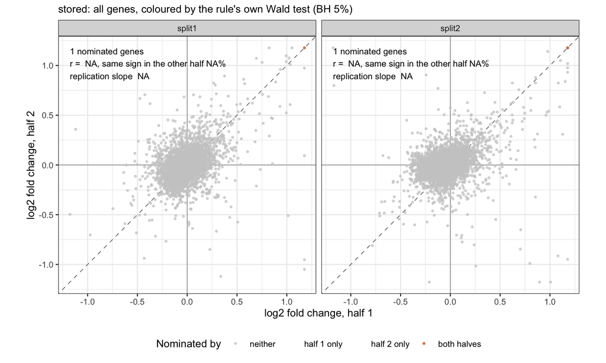

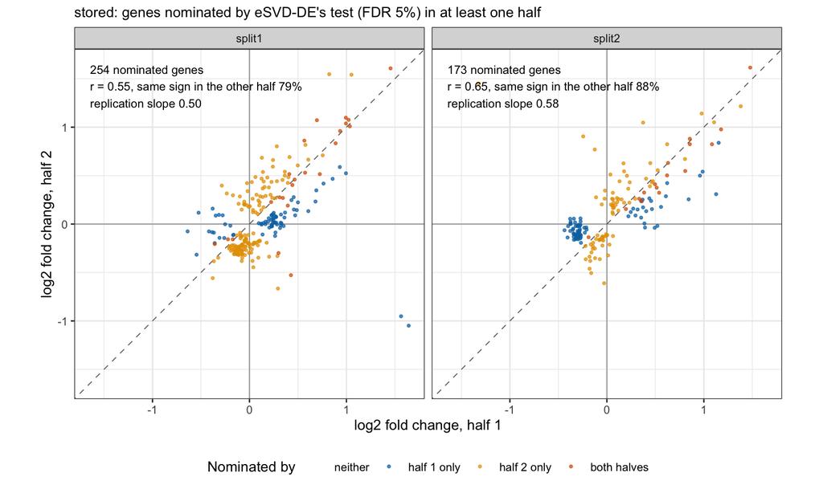

| split | score | z_rms | r_all | score_cross | own_genes | own_both | own_r | own_sign | own_slope | esvd_r | esvd_sign | esvd_slope |
| --- | --- | --- | --- | --- | --- | --- | --- | --- | --- | --- | --- | --- |
| split1 | -0.26 | 0.50 | 0.41 | -0.42 | 1 | 1 | NA | NA | NA | 0.55 | 0.79 | 0.50 |
| split2 | -0.26 | 0.52 | 0.33 | -0.41 | 1 | 1 | NA | NA | NA | 0.65 | 0.88 | 0.58 |

## 3.2 `null_rescaled`

Over all 5256 genes the replicate score of `null_rescaled` is -0.57 and -0.55 nats per gene in the two splits with `z_rms` 1.04 and 1.00, and the two halves’ logFC correlate at 0.42 and 0.34. Its own Wald test nominates 272 and 184 genes in at least one half, of which 21 and 14 in both halves.

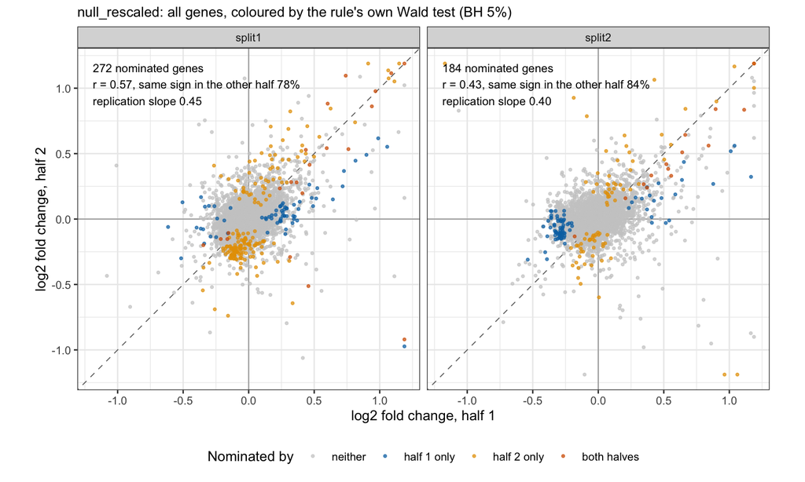

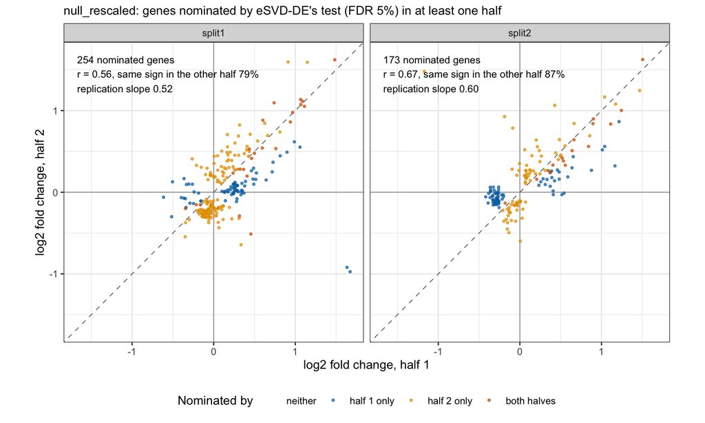

| split | score | z_rms | r_all | score_cross | own_genes | own_both | own_r | own_sign | own_slope | esvd_r | esvd_sign | esvd_slope |
| --- | --- | --- | --- | --- | --- | --- | --- | --- | --- | --- | --- | --- |
| split1 | -0.57 | 1.04 | 0.42 | -0.61 | 272 | 21 | 0.57 | 0.78 | 0.45 | 0.56 | 0.79 | 0.52 |
| split2 | -0.55 | 1.00 | 0.34 | -0.61 | 184 | 14 | 0.43 | 0.84 | 0.40 | 0.67 | 0.87 | 0.60 |

## 3.3 `deshrunk`

Over all 5256 genes the replicate score of `deshrunk` is 0.18 and 0.17 nats per gene in the two splits with `z_rms` 0.44 and 0.43, and the two halves’ logFC correlate at 0.41 and 0.33. Its own Wald test nominates 36 and 39 genes in at least one half, of which 9 and 10 in both halves.

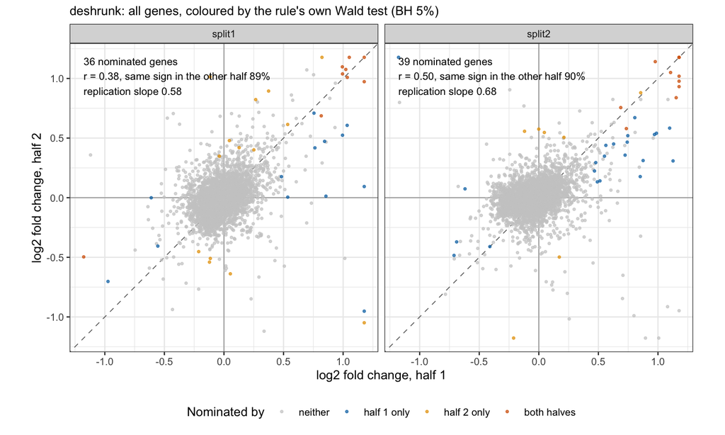

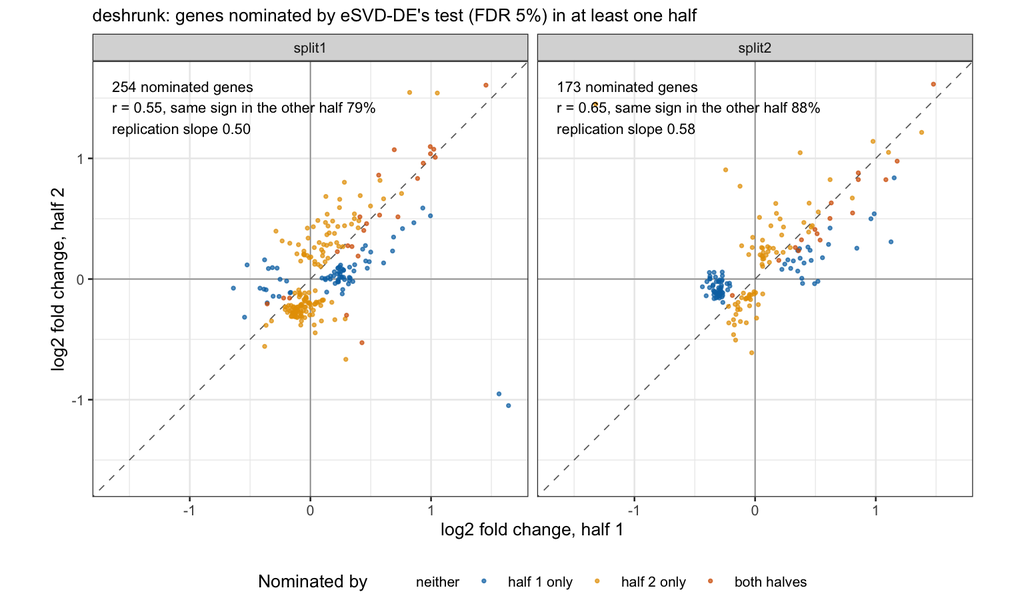

| split | score | z_rms | r_all | score_cross | own_genes | own_both | own_r | own_sign | own_slope | esvd_r | esvd_sign | esvd_slope |
| --- | --- | --- | --- | --- | --- | --- | --- | --- | --- | --- | --- | --- |
| split1 | 0.18 | 0.44 | 0.41 | -0.08 | 36 | 9 | 0.38 | 0.89 | 0.58 | 0.55 | 0.79 | 0.50 |
| split2 | 0.17 | 0.43 | 0.33 | -0.09 | 39 | 10 | 0.50 | 0.90 | 0.68 | 0.65 | 0.88 | 0.58 |

## 3.4 `raw`

Over all 5256 genes the replicate score of `raw` is -0.52 and -0.44 nats per gene in the two splits with `z_rms` 1.17 and 1.24, and the two halves’ logFC correlate at 0.43 and 0.36. Its own Wald test nominates 397 and 298 genes in at least one half, of which 47 and 48 in both halves.

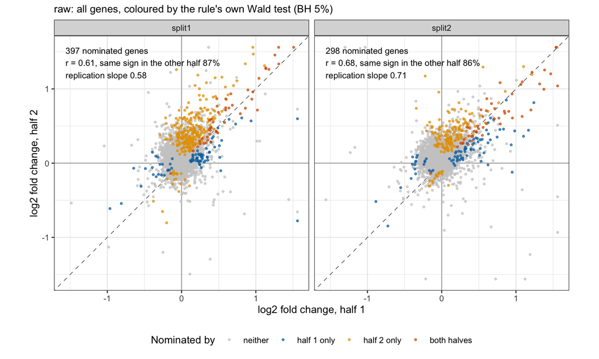

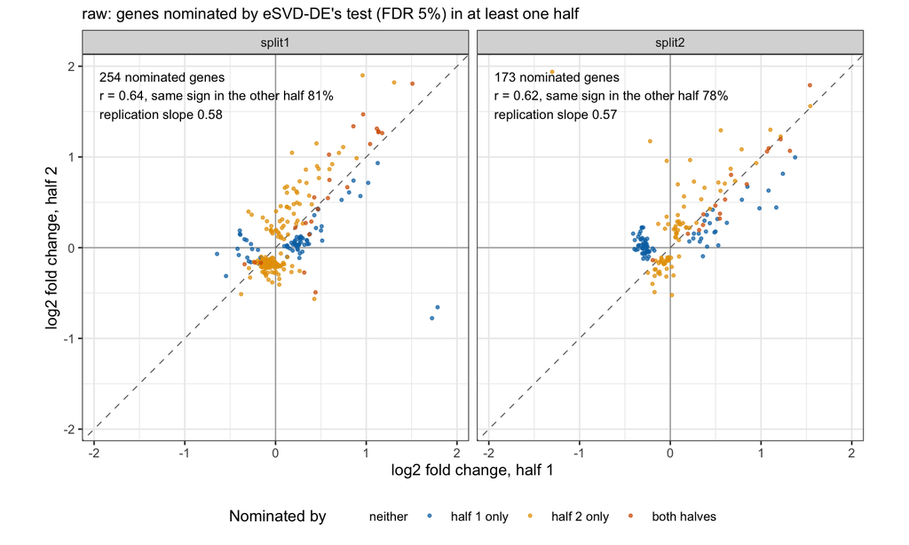

| split | score | z_rms | r_all | score_cross | own_genes | own_both | own_r | own_sign | own_slope | esvd_r | esvd_sign | esvd_slope |
| --- | --- | --- | --- | --- | --- | --- | --- | --- | --- | --- | --- | --- |
| split1 | -0.52 | 1.17 | 0.43 | -0.48 | 397 | 47 | 0.61 | 0.87 | 0.58 | 0.64 | 0.81 | 0.58 |
| split2 | -0.44 | 1.24 | 0.36 | -0.46 | 298 | 48 | 0.68 | 0.86 | 0.71 | 0.62 | 0.78 | 0.57 |

## 3.5 `raw_null`

Over all 5256 genes the replicate score of `raw_null` is -0.56 and -0.54 nats per gene in the two splits with `z_rms` 0.83 and 0.84, and the two halves’ logFC correlate at 0.40 and 0.29. Its own Wald test nominates 11 and 9 genes in at least one half, of which 3 and 1 in both halves.

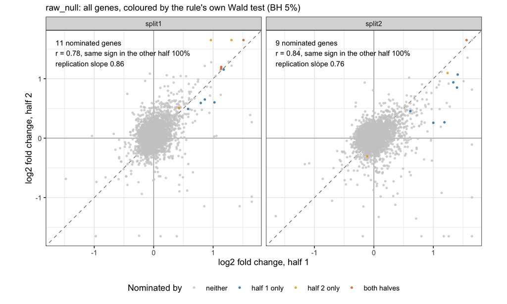

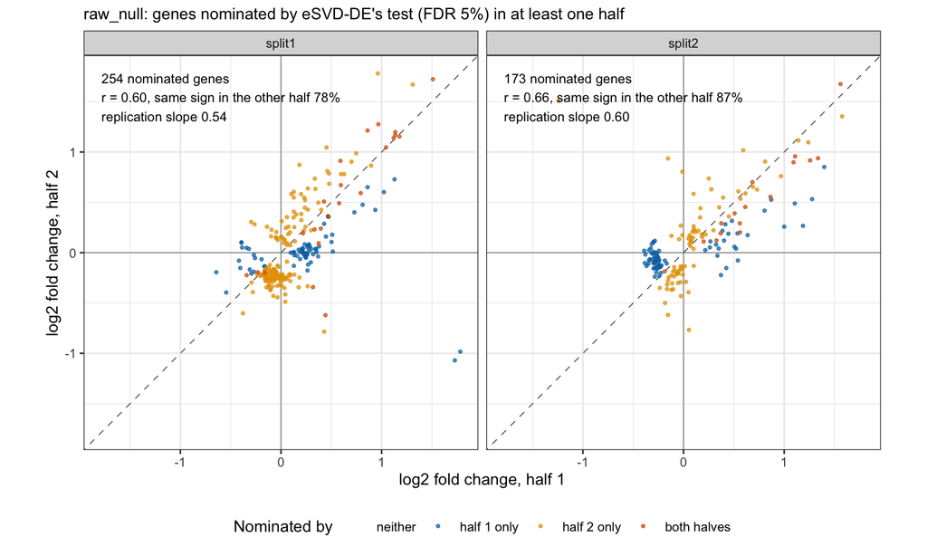

| split | score | z_rms | r_all | score_cross | own_genes | own_both | own_r | own_sign | own_slope | esvd_r | esvd_sign | esvd_slope |
| --- | --- | --- | --- | --- | --- | --- | --- | --- | --- | --- | --- | --- |
| split1 | -0.56 | 0.83 | 0.40 | -0.57 | 11 | 3 | 0.78 | 1 | 0.86 | 0.60 | 0.78 | 0.54 |
| split2 | -0.54 | 0.84 | 0.29 | -0.58 | 9 | 1 | 0.84 | 1 | 0.76 | 0.66 | 0.87 | 0.60 |

## 3.6 `donor_wls`

Over all 5256 genes the replicate score of `donor_wls` is -0.37 and -0.18 nats per gene in the two splits with `z_rms` 1.20 and 1.34, and the two halves’ logFC correlate at 0.27 and 0.07. Its own Wald test nominates 273 and 303 genes in at least one half, of which 21 and 27 in both halves.

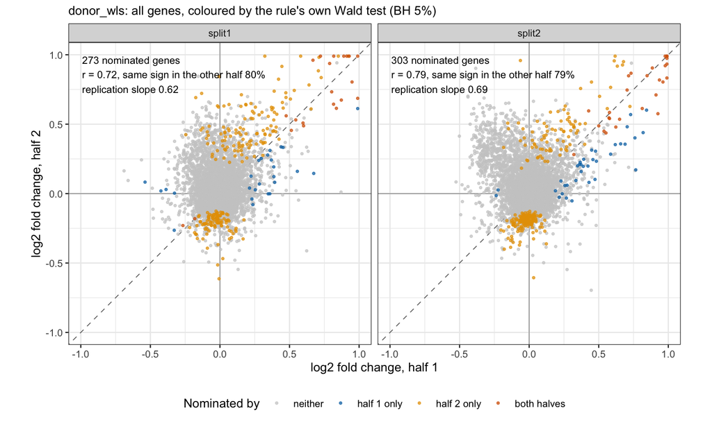

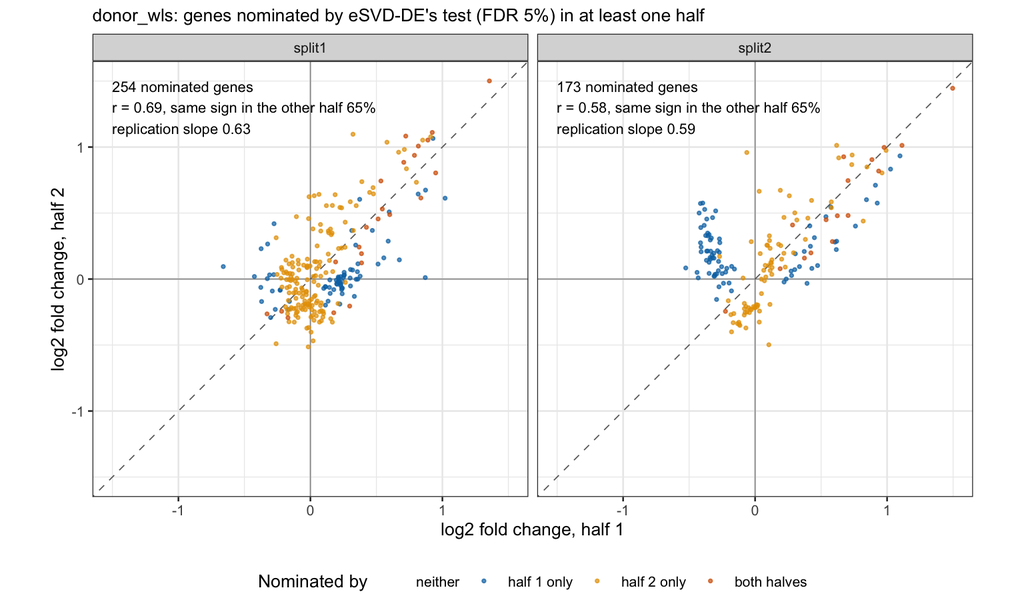

| split | score | z_rms | r_all | score_cross | own_genes | own_both | own_r | own_sign | own_slope | esvd_r | esvd_sign | esvd_slope |
| --- | --- | --- | --- | --- | --- | --- | --- | --- | --- | --- | --- | --- |
| split1 | -0.37 | 1.20 | 0.27 | -0.42 | 273 | 21 | 0.72 | 0.80 | 0.62 | 0.69 | 0.65 | 0.63 |
| split2 | -0.18 | 1.34 | 0.07 | -0.37 | 303 | 27 | 0.79 | 0.79 | 0.69 | 0.58 | 0.65 | 0.59 |

## 3.7 `gap_trend`

Over all 5256 genes the replicate score of `gap_trend` is -0.43 and -0.27 nats per gene in the two splits with `z_rms` 1.14 and 1.27, and the two halves’ logFC correlate at 0.32 and 0.18. Its own Wald test nominates 158 and 186 genes in at least one half, of which 11 and 10 in both halves.

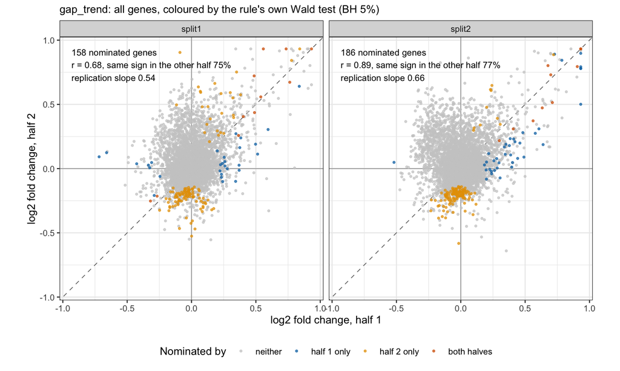

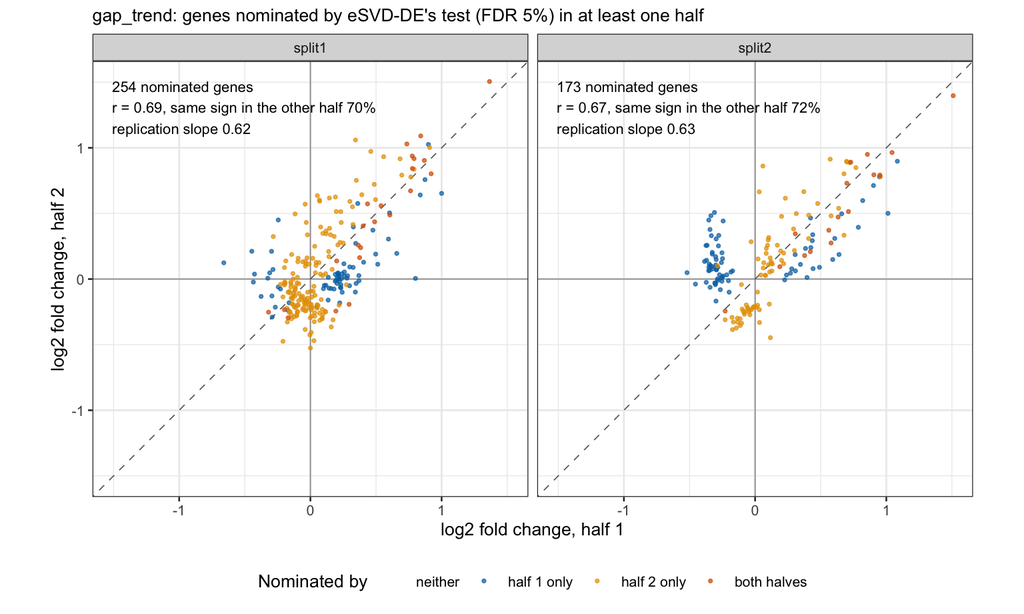

| split | score | z_rms | r_all | score_cross | own_genes | own_both | own_r | own_sign | own_slope | esvd_r | esvd_sign | esvd_slope |
| --- | --- | --- | --- | --- | --- | --- | --- | --- | --- | --- | --- | --- |
| split1 | -0.43 | 1.14 | 0.32 | -0.49 | 158 | 11 | 0.68 | 0.75 | 0.54 | 0.69 | 0.70 | 0.62 |
| split2 | -0.27 | 1.27 | 0.18 | -0.46 | 186 | 10 | 0.89 | 0.77 | 0.66 | 0.67 | 0.72 | 0.63 |

## 3.8 `embed_prior`

Over all 5256 genes the replicate score of `embed_prior` is -0.36 and -0.18 nats per gene in the two splits with `z_rms` 1.20 and 1.35, and the two halves’ logFC correlate at 0.27 and 0.07. Its own Wald test nominates 277 and 314 genes in at least one half, of which 20 and 27 in both halves.

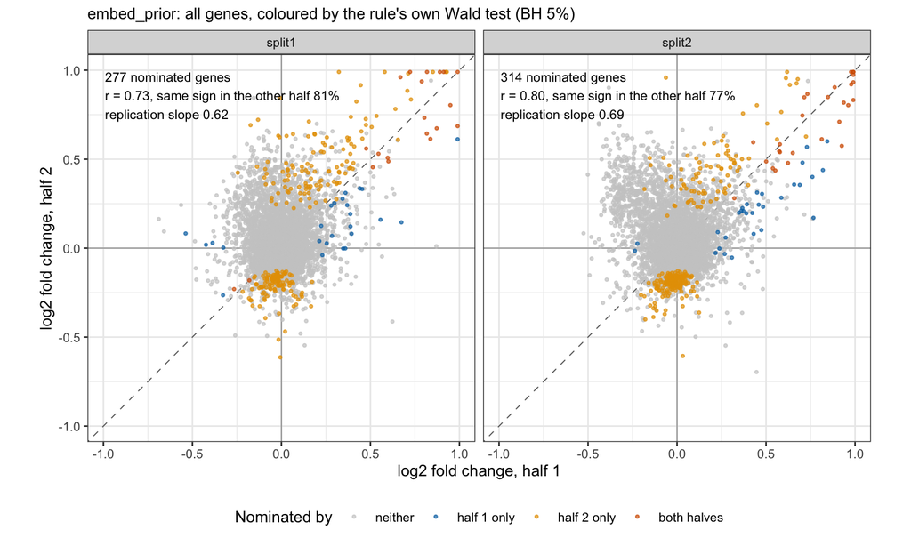

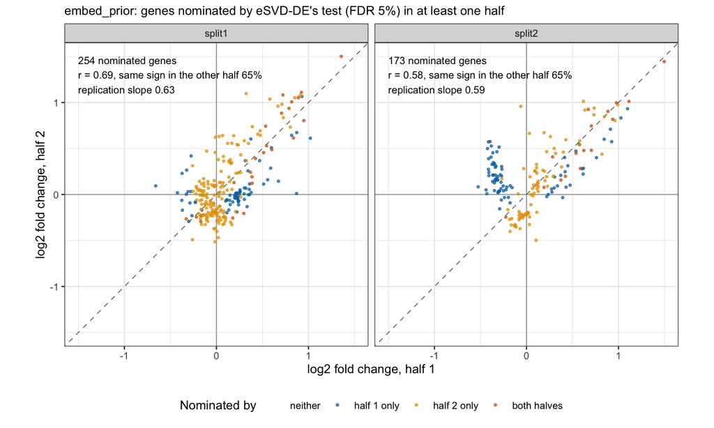

| split | score | z_rms | r_all | score_cross | own_genes | own_both | own_r | own_sign | own_slope | esvd_r | esvd_sign | esvd_slope |
| --- | --- | --- | --- | --- | --- | --- | --- | --- | --- | --- | --- | --- |
| split1 | -0.36 | 1.20 | 0.27 | -0.42 | 277 | 20 | 0.73 | 0.81 | 0.62 | 0.69 | 0.65 | 0.63 |
| split2 | -0.18 | 1.35 | 0.07 | -0.37 | 314 | 27 | 0.80 | 0.77 | 0.69 | 0.58 | 0.65 | 0.59 |

## 3.9 `state_adjusted`

Over all 5256 genes the replicate score of `state_adjusted` is -0.99 and -0.96 nats per gene in the two splits with `z_rms` 0.93 and 0.96, and the two halves’ logFC correlate at 0.13 and 0.11. Its own Wald test nominates 19 and 17 genes in at least one half, of which 0 and 0 in both halves.

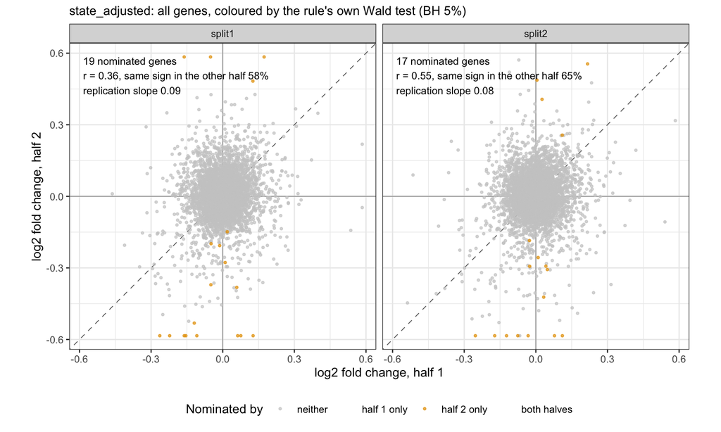

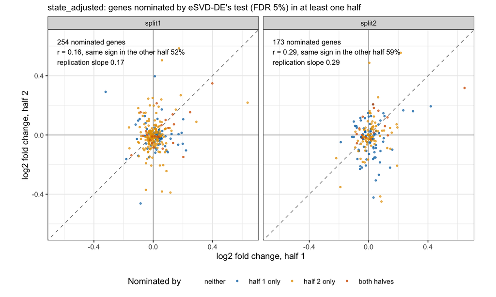

[output not shown]

## 3.10 `raw@esvd_nofloor`

Over all 5256 genes the replicate score of `raw@esvd_nofloor` is -0.64 and -0.65 nats per gene in the two splits with `z_rms` 1.06 and 1.06, and the two halves’ logFC correlate at 0.38 and 0.28. Its own Wald test nominates 125 and 134 genes in at least one half, of which 11 and 10 in both halves.

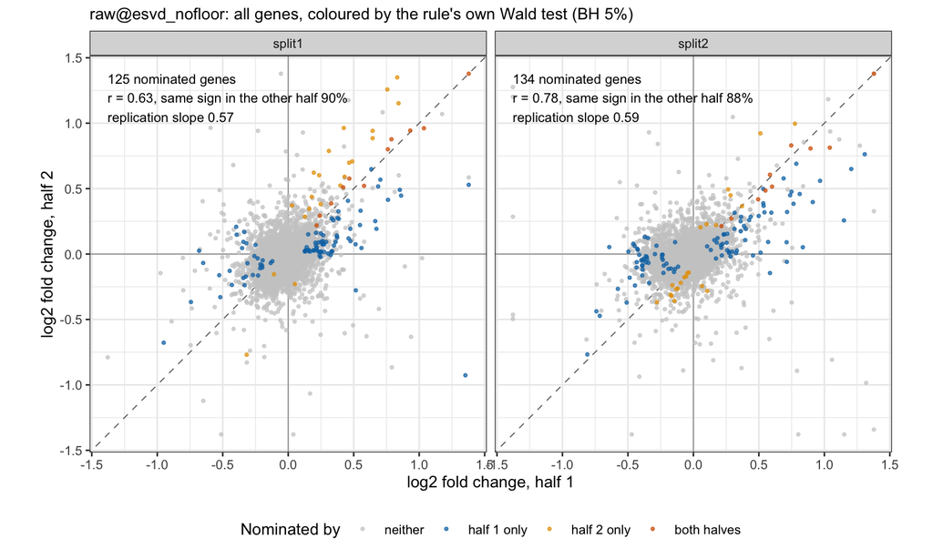

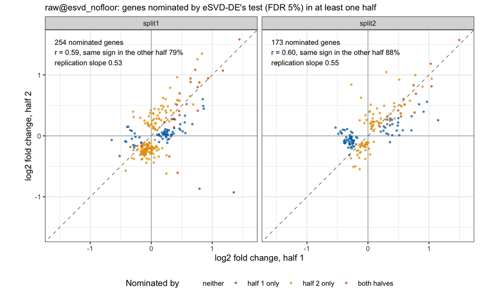

| split | score | z_rms | r_all | score_cross | own_genes | own_both | own_r | own_sign | own_slope | esvd_r | esvd_sign | esvd_slope |
| --- | --- | --- | --- | --- | --- | --- | --- | --- | --- | --- | --- | --- |
| split1 | -0.64 | 1.06 | 0.38 | -0.63 | 125 | 11 | 0.63 | 0.90 | 0.57 | 0.59 | 0.79 | 0.53 |
| split2 | -0.65 | 1.06 | 0.28 | -0.63 | 134 | 10 | 0.78 | 0.88 | 0.59 | 0.60 | 0.88 | 0.55 |

## 3.11 `donor_wls@esvd_nofloor`

Over all 5256 genes the replicate score of `donor_wls@esvd_nofloor` is -0.61 and -0.58 nats per gene in the two splits with `z_rms` 1.04 and 1.07, and the two halves’ logFC correlate at 0.34 and 0.27. Its own Wald test nominates 95 and 108 genes in at least one half, of which 11 and 8 in both halves.

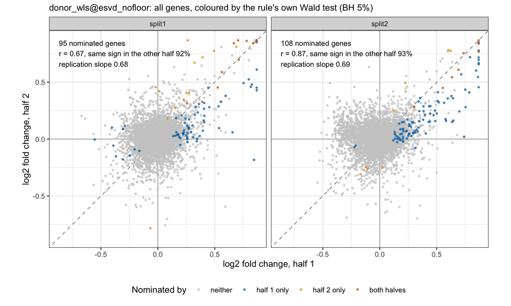

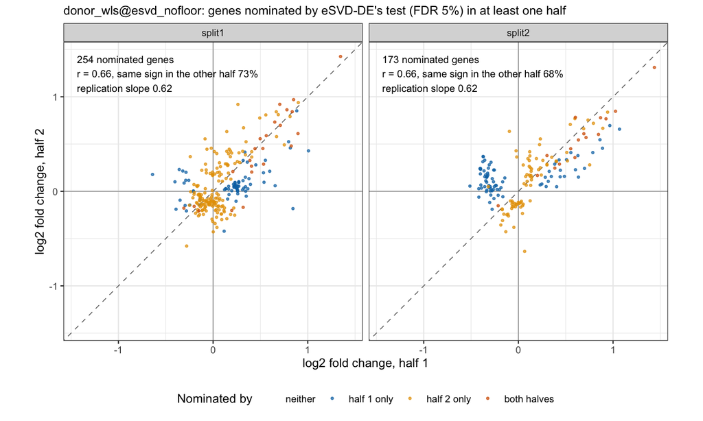

| split | score | z_rms | r_all | score_cross | own_genes | own_both | own_r | own_sign | own_slope | esvd_r | esvd_sign | esvd_slope |
| --- | --- | --- | --- | --- | --- | --- | --- | --- | --- | --- | --- | --- |
| split1 | -0.61 | 1.04 | 0.34 | -0.61 | 95 | 11 | 0.67 | 0.92 | 0.68 | 0.66 | 0.73 | 0.62 |
| split2 | -0.58 | 1.07 | 0.27 | -0.61 | 108 | 8 | 0.87 | 0.93 | 0.69 | 0.66 | 0.68 | 0.62 |

## 3.12 `state_adjusted@esvd_nofloor`

Over all 5256 genes the replicate score of `state_adjusted@esvd_nofloor` is -1.09 and -1.06 nats per gene in the two splits with `z_rms` 0.94 and 0.97, and the two halves’ logFC correlate at 0.05 and 0.04. Its own Wald test nominates 0 and 0 genes in at least one half, of which 0 and 0 in both halves.

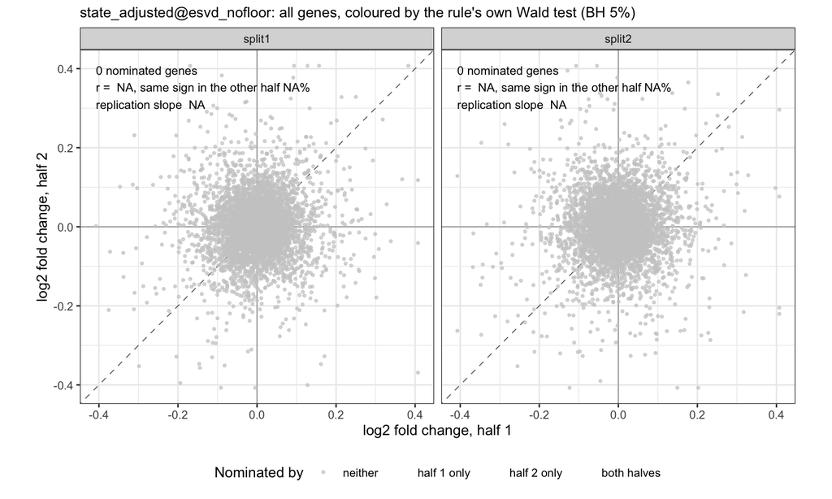

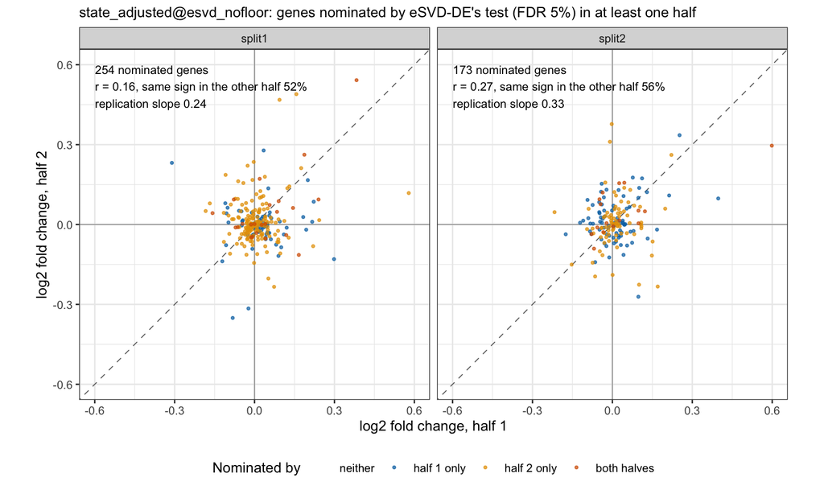

| split | score | z_rms | r_all | score_cross | own_genes | own_both | own_r | own_sign | own_slope | esvd_r | esvd_sign | esvd_slope |
| --- | --- | --- | --- | --- | --- | --- | --- | --- | --- | --- | --- | --- |
| split1 | -1.09 | 0.94 | 0.05 | -0.63 | 0 | 0 | NA | NA | NA | 0.16 | 0.52 | 0.24 |
| split2 | -1.06 | 0.97 | 0.04 | -0.63 | 0 | 0 | NA | NA | NA | 0.27 | 0.56 | 0.33 |